# Unsupervised Machine Learning with K-Means

## K-Means Cluster Analysis

Clustering is a broad topic with different techniques designed to achieve different goals. But all of these techniques seek to group data into subsets (or clusters) of related data. In doing this we can find relationships between variables (or levels across variables), reduce the dimension of the data, describe the similarly (or dissimilarity) of the data with statistics, etc. Today we’ll discuss one of the most popular clustering techniques, K-Means.

When we cluster observations, we want observations in the same group to be similar. So we take the data as a whole, use some measure of similarity, and iteratively group the data based on how similar observations are to each other. This sounds like KNN, but with KNN we were trying to classify the data. That is, we had a response variable. KNN is a **supervised** learning, clustering is **unsupervised**. Because there is not a response variable clustering seeks relationships without being trained (hence no training and test set). And since there is no response, there is no concrete measure of “goodness” in K-Means Clustering. For this and other reasons, typically clustering is not a means to an end but an input into other processes.

For example, often we use Clustering as a data reduction technique. Cluster assignment can stand in for various other variables in a model (similar to using Principle Component Analysis as a model input). It can also be used to target a certain group based on similar traits. Say we get market data on the pool of recruits in an area. We can cluster the associated recruiting stations based on the target pool and design specific marketing campaigns. Unlike many statistical techniques, clustering is primarily descriptive, and we will not draw statistical inference from it (no hypothesis testing here).

For this example we will use the built-in `USArrests` data.

```r
df<-USArrests
head(df)
```

|  | Murder | Assault | UrbanPop | Rape |
| --- | --- | --- | --- | --- |
| Alabama | 13.2 | 236 | 58 | 21.2 |
| Alaska | 10.0 | 263 | 48 | 44.5 |
| Arizona | 8.1 | 294 | 80 | 31.0 |
| Arkansas | 8.8 | 190 | 50 | 19.5 |
| California | 9.0 | 276 | 91 | 40.6 |
| Colorado | 7.9 | 204 | 78 | 38.7 |

```r
which(is.na(df))
```

```
## integer(0)
```

```r
df<-na.omit(df) #clustering will not work if their are any NAs
```

Many clustering techniques use a form of distance to determine groupings, this can lead to arbitrary groups based on units or scale (foot size vs weight in grams). To avoid this we need to scale our data. The easiest way is the scale() function which uses the $Z$ score.

```r
df<-scale(df)
head(df)
```

```
##                Murder   Assault   UrbanPop         Rape
## Alabama    1.24256408 0.7828393 -0.5209066 -0.003416473
## Alaska     0.50786248 1.1068225 -1.2117642  2.484202941
## Arizona    0.07163341 1.4788032  0.9989801  1.042878388
## Arkansas   0.23234938 0.2308680 -1.0735927 -0.184916602
## California 0.27826823 1.2628144  1.7589234  2.067820292
## Colorado   0.02571456 0.3988593  0.8608085  1.864967207
```

So what is the math. There are many different distance measures that are used in cluster analysis, but the easiest to demonstrate is the Euclidean Distance.

$$d_{euc}(x,y)=\sqrt{\sum_{i=1}^n(x_i-y_i)^2}$$

```r
(1.24256408-0.50786248)^2+(0.7828393-1.1068225)^2+(-0.5209066+1.2117642)^2+(-0.003416473- 2.484202941)^2
```

```
## [1] 7.310286
```

Other distance options include

- Manhattan
- correlation distance
  - Spearman
  - Kendall
  - Pearson

I really do not want to do all this by hand, so lets use a package that will create a 50X50 matrix showing the distances between each state based on the four variables.

```r
distance<-get_dist(df)
fviz_dist(distance)
```

[output not shown]

### K-Means Clustering

K Means clustering is a very common unsupervised machine learning algorithm for partitioning data into $k$ groups (i.e. $k$ clusters).  
In K Means clustering we predetermine the number of clusters and then each cluster is represented by its center (centroid or medoid depending on the application) which is the mean of the points assigned to that cluster.

There are many variations of the the K Means algorithm. Basically, its an iterative process of partitioning the data into chunks and grouping the partitions based on the dissimilarity calculations. The algorithm randomly selects $k$ data points and those become the starting centroids. Then, each of the remaining data points are grouped with their nearest centroid. This creates $k$ clusters. After this step, the new center for each cluster is found (mean distance between the cluster members). Once the new centroids are determined each data point is compared to the new centroids to determine if they should change cluster. Once points are reassinged, new centroids are found and the process repeats. This continues until an iteration occurs where there are no changes.

We will use kmeans() from the built in stats package and fviz_cluster() from the factoextra package to complete our clustering. There are other options available as well.

```r
k2<-kmeans(df, centers=2, nstart=25)
str(k2)
#just print out the first 10 states' assignment
k2$cluster[1:10]
k2$centers
# make more for comparisons
k3<-kmeans(df, centers=3, nstart=25)
k4<-kmeans(df, centers=4, nstart=25)
k5<-kmeans(df, centers=5, nstart=25)
k6<-kmeans(df, centers=6, nstart=25)
```

[output not shown]

Lets look at this graphically. `fviz_cluster` uses Principal Component Analysis to bring the data down to two-dimensions for easy viewing.

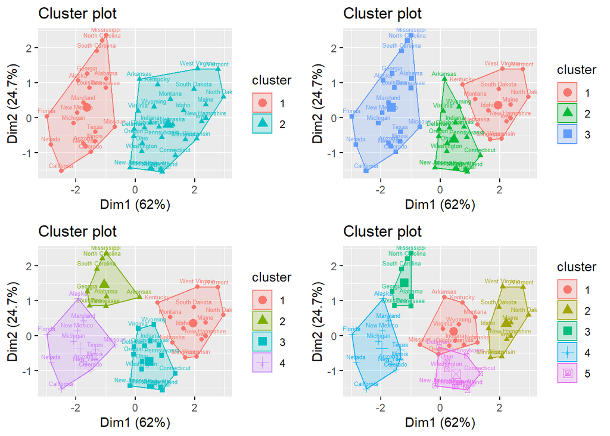

```r
p1<-fviz_cluster(k2,data=df,labelsize = 5)
p2<-fviz_cluster(k3,data=df,labelsize = 5)
p3<-fviz_cluster(k4,data=df,labelsize = 5)
p4<-fviz_cluster(k5,data=df,labelsize = 5)

grid.arrange(p1,p2,p3,p4,nrow=2)
```

Now looking at the differences, how can we group states?

### How many Clusters.

The intent with cluster is to minimize the variation within clusters (build similar groups). Performance is in the eye of the beholder, its up to the analyst to determine the right number of clusters. The common tactic is to plot the variance and examine.

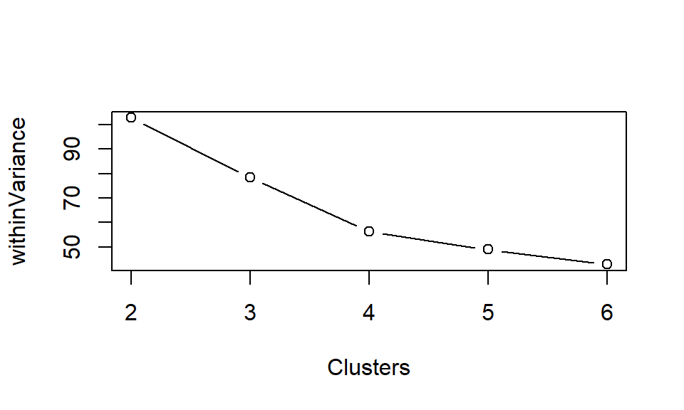

```r
Clusters<-(2:6)
withinVariance<-c(sum(k2$tot.withinss),sum(k3$tot.withinss),sum(k4$tot.withinss),sum(k5$tot.withinss),sum(k6$tot.withinss))
plot(Clusters, withinVariance, type="b")
```

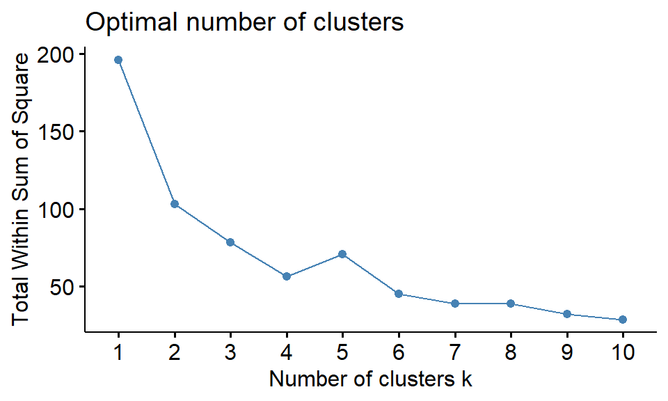

```r
fviz_nbclust(df,kmeans,method='wss')
```

So the bend in the curve is at 4 Clusters, so lets go with that. We can feel good that we have assigned clusters, but we have this crazy scale and cannot really do analysis. So lets assign our data the respective clusters and do some descriptive stats.

```r
df<-USArrests %>% add_rownames("State") %>% mutate(Cluster=k4$cluster)
head(df)# now we can make cluster a response and see if there is something interesting
```

| State | Murder | Assault | UrbanPop | Rape | Cluster |
| --- | --- | --- | --- | --- | --- |
| Alabama | 13.2 | 236 | 58 | 21.2 | 2 |
| Alaska | 10.0 | 263 | 48 | 44.5 | 4 |
| Arizona | 8.1 | 294 | 80 | 31.0 | 4 |
| Arkansas | 8.8 | 190 | 50 | 19.5 | 2 |
| California | 9.0 | 276 | 91 | 40.6 | 4 |
| Colorado | 7.9 | 204 | 78 | 38.7 | 4 |

```r
# take a look at some stats
df %>%
  group_by(Cluster) %>%
  summarize(across(where(is.numeric), mean))
```

| Cluster | Murder | Assault | UrbanPop | Rape |
| --- | --- | --- | --- | --- |
| 1 | 3.60000 | 78.53846 | 52.07692 | 12.17692 |
| 2 | 13.93750 | 243.62500 | 53.75000 | 21.41250 |
| 3 | 5.65625 | 138.87500 | 73.87500 | 18.78125 |
| 4 | 10.81538 | 257.38462 | 76.00000 | 33.19231 |

### Your Turn

Read in the table from https://www.worldometers.info/coronavirus/country/us/ and cluster the states based on the Covid-19 data (use webscraping). You will have to select which columns to use and then clean and scale the data.

If you’re not comfortable with scraping use the provided file from the CDC. You’ll need to do more work with that file though.